# Monte Carlo Sample Calculations

Victor Tsang (z5209633)

2022-09-22

#### Setup

Source our helper functions and set our parameters.

```r
source("new-method-functions.R")

set.seed(2022)

n = 30                             # Number of fossil samples in each dataset
theta.true = 10000                 # True extinction date
K = 20000                          # Upper bound for fossil ages

dating_error.mean = 0              # True mean of radiocarbon dating error
dating_error.sd = 272              # True Standard deviation

alpha = 0.05                       # 95% confidence interval
```

Then, simulate some data

```r
W = runif(n=n, min=theta.true, max=K) + rnorm(n=n, mean=dating_error.mean, sd=dating_error.sd)
m=min(W)
m
```

```
## [1] 9784.822
```

**Goal:** Find an expression for the variance of our estimator. We have:

$$\begin{align*}
q^{-\frac{1}{n}} &= 1 - \frac{F_\varepsilon(m -
\hat{\theta}_q)}{F_\varepsilon(K - \hat{\theta}_q)} +
\frac{\phi}{F_\varepsilon(K - \hat{\theta}_q)}; &\phi
= \int^{m-\theta}_{-\infty} \frac{K - m}{K - e - \theta }
f_\varepsilon(e) de \\
\implies \phi &= F_\varepsilon(m - \hat{\theta}_q) -
(1-q^{-\frac{1}{n}}) F_\varepsilon(K - \hat{\theta}_q)
\end{align*}$$

**(1)** — Since $\hat\phi = \frac{1}{B} \sum_{b=1}^B \frac{K-m}{K-e_b-\theta_q}$, we can apply the central limit theorem:

$$\sqrt{B} \Big[ \hat\phi - \phi \Big] \overset{D}{\sim}
\mathcal{N}\Big(0, \mathrm{Var}(\phi) \Big)$$

**(2)** — Applying the delta method, we get the asymptotic distribution of $\hat\theta$:

$$\sqrt{B} \Big[ \hat\theta - \theta \Big] \overset{D}{\sim}
\mathcal{N}\left(0,\mathrm{Var}(\phi) \cdot \left[\frac{d}{d\theta} \phi
\right]^{-2} \right)
\implies \mathrm{Var}\{\hat{\theta}_q\} =
\frac{\mathrm{Var}(\phi)}{\left[\frac{d}{d\theta} \phi \right]^{2}}
\approx \frac{\mathrm{Var}(\hat\phi)}{\left[\frac{d}{d\theta}
\phi\right]^{2}}$$

**(3)** — $\mathrm{Var}(\hat\phi)$

$$\begin{align*}
\mathrm{Var}(\hat\phi)
&= \mathrm{Var}\left\{\frac{1}{B} \sum_{b=1}^B
\frac{K-m}{K-e_b-\theta_q} \right\} \\
&= \frac{1}{B} {\mathrm{Var}\left\{ \frac{K-m}{K-e-\theta_q}
\right\}} \\
&\approx \frac{1}{B} \mathrm{Var}\left\{
\frac{K-m}{K-e-\hat\theta_q} \right\} = \frac{1}{B} \sigma_\phi^2
\end{align*}$$

We can estimate $\sigma_\phi^2$ for our upper and lower bounds by taking the sample variance of $\frac{K-m}{K-e-\hat\theta_q}$, where $\hat\theta_q$ is estimated using some arbitrary $B$ for our monte carlo integral.

Initial estimates of $\hat\theta_q$:

```r
B = 500                            # Arbitrary initial B (number of monte carlo samples)
u=matrix(runif(n*B, 0, 1), ncol=B) # Base MC Samples to plug into our method
uniroot.interval = c(2000, 19500)  # Search interval for uniroot (TODO - a better way of picking this?)

init.CI = estimate_CI.mc(alpha, n, K, W, u, dating_error.mean, dating_error.sd, uniroot.interval)
init.CI
```

```
## $CI.lower
## [1] 8441.16
##
## $CI.upper
## [1] 10180.41
```

Use this initial estimate to estimate $\sigma_\phi^2$

```r
e = list()
e$lower = rtnorm(n, mean=dating_error.mean, sd=dating_error.sd, a=-Inf, b=m-init.CI$CI.lower)
e$upper = rtnorm(n, mean=dating_error.mean, sd=dating_error.sd, a=-Inf, b=m-init.CI$CI.upper)
e
```

```
## $lower
##  [1]  179.76399  675.23842 -155.08554 -166.27081  215.16924 -440.39263
##  [7]  -98.24560  152.01556   11.60925  222.40212  -10.96745  268.34488
## [13]  136.41075  -46.34212 -296.72830 -382.89463  156.38569  166.63357
## [19] -385.42419  -86.35283  168.46756 -256.24063 -300.70761  225.53110
## [25]  -56.78409 -450.13352  114.98639  -79.03090  230.53391   11.37332
##
## $upper
##  [1] -438.8735 -457.8521 -656.3242 -409.1367 -563.7655 -418.5190 -565.6563
##  [8] -564.2762 -597.5125 -494.4692 -485.6161 -426.0434 -444.9265 -695.0561
## [15] -550.1038 -693.6261 -483.2335 -511.2940 -430.5122 -576.1599 -459.9953
## [22] -464.5018 -633.3833 -737.3238 -438.5047 -436.7348 -429.8922 -400.4578
## [29] -456.4351 -655.4125
```

```r
sigma.phi = list()
sigma.phi$lower = sd((K - m)/(K-e$lower-init.CI$CI.lower))
sigma.phi$upper = sd((K - m)/(K-e$upper-init.CI$CI.upper))
sigma.phi
```

```
## $lower
## [1] 0.01969968
##
## $upper
## [1] 0.00931719
```

**(4)** — $\frac{d}{d\theta} \phi$

$$\begin{align*}
\frac{d}{d\theta} \phi
&= \frac{d}{d\theta} \left[ F_\varepsilon(m - {\theta}_q) -
(1-q^{-1/n}) F_\varepsilon(K - {\theta}_q) \right] \\
&= (1-q^{-1/n}) f_\varepsilon(K - {\theta}_q) -
f_\varepsilon(m - {\theta}_q) \\
&\approx (1-q^{-1/n}) f_\varepsilon(K - \hat{\theta}_q) -
f_\varepsilon(m - \hat{\theta}_q)
\end{align*}$$

**(5)** — Put it all together:

$$\mathrm{Var}\{\hat{\theta}_q\}
\approx \frac{1}{B} \mathrm{Var}\left\{ \frac{K-m}{K-e-\hat\theta_q}
\right\} \left[(1-q^{-1/n}) f_\varepsilon(K - \hat{\theta}_q) -
f_\varepsilon(m - \hat{\theta}_q) \right]^{-2}$$

$$\implies B
\approx \left[\mathrm{Var}\{\hat{\theta}_q\}\right]^{-1}
\mathrm{Var}\left\{ \frac{K-m}{K-e-\hat\theta_q} \right\}
\left[(1-q^{-1/n}) f_\varepsilon(K - \hat{\theta}_q) - f_\varepsilon(m -
\hat{\theta}_q) \right]^{-2}$$

```r
optimal_B = list()
optimal_B$lower = find_optimal_B(target_sd=0.2*dating_error.sd,
                                 q=alpha/2,
                                 theta=init.CI$CI.lower,
                                 K, n, m,
                                 sd.phi=sigma.phi$lower,
                                 dating_error.mean,
                                 dating_error.sd)
```

```
## [1] "f(K-theta.hat.q) 0"
## [1] "f(m-theta.hat.q) 7.3673295039663e-09"
```

```r
optimal_B$upper = find_optimal_B(target_sd=0.2*dating_error.sd,
                                 q=(1 - alpha/2),
                                 theta=init.CI$CI.upper,
                                 K, n, m,
                                 sd.phi=sigma.phi$upper,
                                 dating_error.mean,
                                 dating_error.sd)
```

```
## [1] "f(K-theta.hat.q) 1.43056009143072e-286"
## [1] "f(m-theta.hat.q) 0.000509367114260151"
```

```r
optimal_B
```

```
## $lower
## [1] 2416019306
##
## $upper
## [1] 0.1130603
```

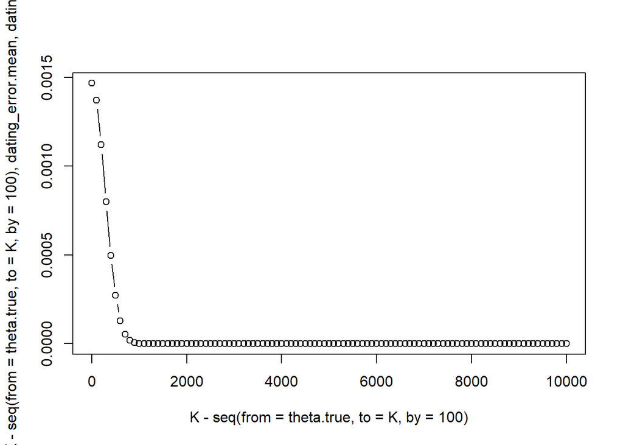

```r
plot(x=K-seq(from=theta.true, to=K, by=100), y=dnorm(K - seq(from=theta.true, to=K, by=100), dating_error.mean, dating_error.sd), type='b')
```

## Checks

Three things to check expected behaviour:

$$\mathrm{Var}(\hat\theta_q), \quad \mathrm{Var}\left\{
\frac{K-m}{K-e-\theta_q} \right\}, \quad \left[(1-q^{-1/n})
f_\varepsilon(K - \hat{\theta}_q) - f_\varepsilon(m - \hat{\theta}_q)
\right]^{-2}$$

### Variance of $\hat\theta_q$

For the purposes of this check, we’ll only look at the lower bound estimate.

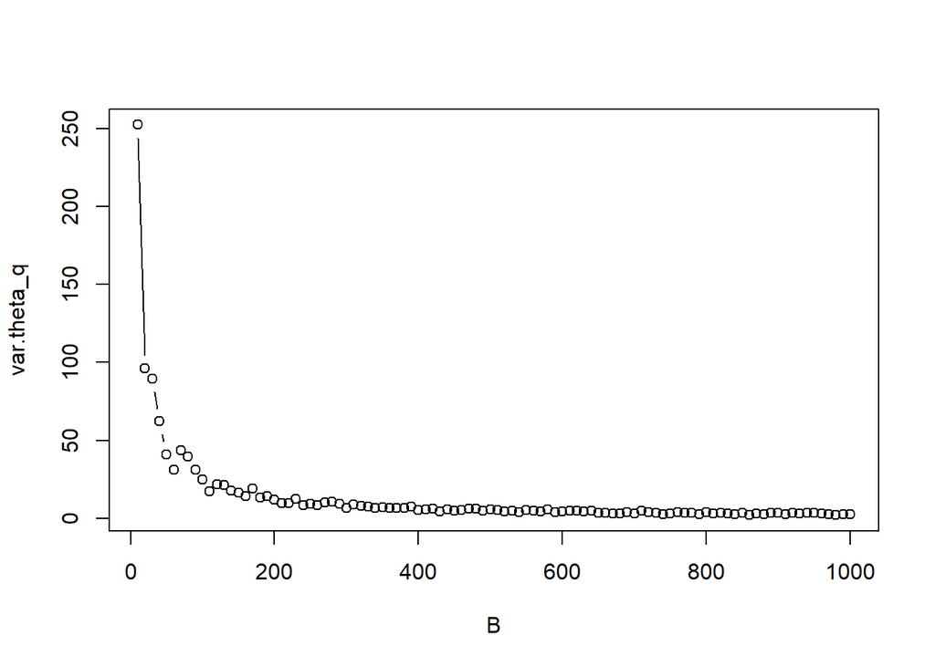

```r
n = 30

num.B = 100
B = seq(from=0, by=10, length.out=num.B) + 10

num.estimates = 100

# Simulate a dataset
W = runif(n=n, min=theta.true, max=K) + rnorm(n=n, mean=dating_error.mean, sd=dating_error.sd)
m=min(W)

var.theta_q = rep(NA, num.B)
seed.count = 1
for (i in 1:num.B) {
  # Generate 100 estimates of \theta_0.025
  theta.hat = rep(NA, num.estimates)
  for (j in 1:num.estimates) {
    # Set different randomisation seed
    set.seed(seed.count)

    u = matrix(runif(n*B[i], min=0, max=1), ncol=B[i])
    theta.hat[j] = estimate_quantile.mc(q=0.025, K, W, u,
                                        dating_error.mean,
                                        dating_error.sd, uniroot.interval)
    seed.count = seed.count+1
  }
  # save sample variance
  var.theta_q[i] = var(theta.hat)
}
plot(B, var.theta_q, type="b")
```

### $\sigma^2_\phi = \mathrm{Var}\left(\frac{K-m}{K-e-\hat\theta_q}\right)$

```r
B = 1000
num.estimates = 1000

sigma2_phi = rep(NA, num.estimates)
for (i in 1:num.estimates) {
  # Get B samples of e
  e = extraDistr::rtnorm(n=B, mean=dating_error.mean, sd=dating_error.sd, a=-Inf, b=m-init.CI$CI.lower)

  sigma2_phi[i] = var((K-m)/(K-e-init.CI$CI.lower))
}
mean(sigma2_phi)
```

```
## [1] 0.0003914763
```

```r
var(sigma2_phi)
```

```
## [1] 3.093428e-10
```

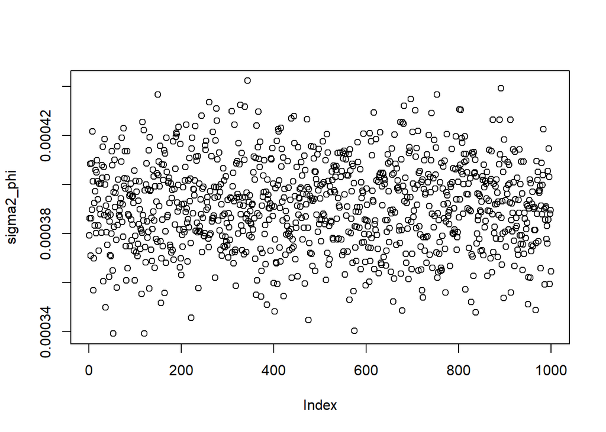

```r
plot(sigma2_phi)
```

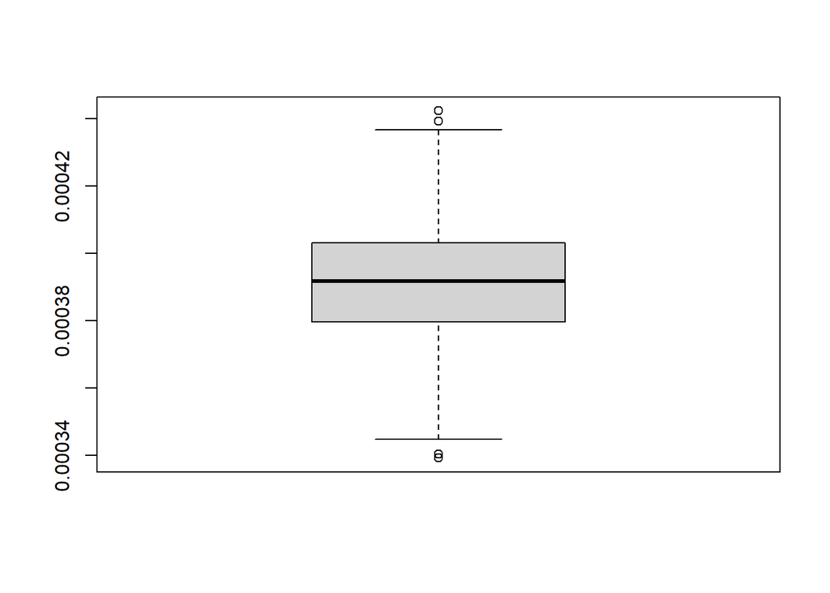

```r
boxplot(sigma2_phi)
```

### Weird term

$$\left[(1-q^{-1/n}) f_\varepsilon(K - \hat{\theta}_q) - f_\varepsilon(m -
\hat{\theta}_q) \right]^{-2}$$

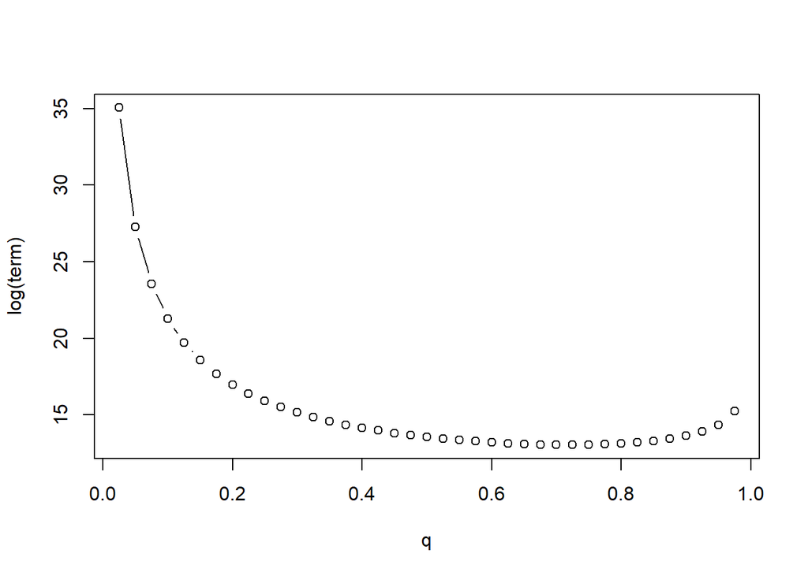

```r
set.seed(2022)
n = 30
B = 200
u = matrix(runif(n*B, min=0, max=1), ncol=B)

q = seq(from=0.025, to=0.975, by=0.025)
theta_q = rep(NA, length(q))
term = rep(NA, length(q))
for (i in 1:length(q) ) {
  # estimate theta_q
  theta_q[i] = estimate_quantile.mc(q=q[i], K, W, u, dating_error.mean,
                               dating_error.sd, c(5000, 19500))
  term[i] = ( (1 - q[i]^(-1/n)) * dnorm(K - theta_q[i], dating_error.mean, dating_error.sd) - dnorm(m - theta_q[i], dating_error.mean, dating_error.sd) )^(-2)
}

plot(x=q, y=log(term), type="b")
```

```r
log(term)
```

```
##  [1] 35.05002 27.26664 23.56087 21.29270 19.73187 18.58088 17.69214 16.98292
##  [9] 16.40282 15.91922 15.50997 15.15949 14.85647 14.59251 14.36125 14.15779
## [17] 13.97830 13.81978 13.67983 13.55657 13.44852 13.35453 13.27372 13.20550
## [25] 13.14951 13.10562 13.07399 13.05505 13.04957 13.05881 13.08462 13.12973
## [33] 13.19821 13.29629 13.43396 13.62846 13.91295 14.36391 15.23339
```

```r
m-theta_q
```

```
##  [1] 1275.808792 1025.593695  881.858753  780.939423  703.128408  639.714602
##  [7]  586.073495  539.454632  498.090049  460.776409  426.657854  395.103358
## [13]  365.633573  337.874764  311.528571  286.351674  262.141362  238.725170
## [19]  215.953300  193.692602  171.821911  150.228102  128.802579  107.438054
## [25]   86.025147   64.448737   42.583634   20.289099   -2.598478  -26.275888
## [31]  -50.988291  -77.052960 -104.897756 -135.128876 -168.657805 -206.967110
## [37] -252.751112 -311.843951 -401.963188
```

```r
dnorm(m - theta_q, dating_error.mean, dating_error.sd)
```

```
##  [1] 2.448974e-08 1.199842e-06 7.652816e-06 2.378749e-05 5.191343e-05
##  [6] 9.230259e-05 1.439467e-04 2.052138e-04 2.742661e-04 3.492890e-04
## [11] 4.286003e-04 5.106922e-04 5.942368e-04 6.780738e-04 7.611912e-04
## [16] 8.427029e-04 9.218275e-04 9.978681e-04 1.070194e-03 1.138222e-03
## [21] 1.201407e-03 1.259219e-03 1.311138e-03 1.356632e-03 1.395150e-03
## [26] 1.426100e-03 1.448835e-03 1.462625e-03 1.466633e-03 1.459872e-03
## [31] 1.441155e-03 1.409014e-03 1.361586e-03 1.296426e-03 1.210186e-03
## [36] 1.098037e-03 9.524464e-04 7.601805e-04 4.921654e-04
```